# Wilcoxons - Week 3, Lecture 1

Author

Hector Gavilanes

```r
library(tidyverse)
library(gsheet)
library(formattable)
library(gridExtra)
```

## Question 1:

**Recall the first dataset from last week. A large credit union awards quarterly bonuses to its employees. To ensure fairness across departments, data on the bonuses are regularly reviewed for equality. Consider the data in the following Google Sheet, which includes the bonus percentage for each employee in two departments.**

```r
# clear environment
rm(list = ls())

# extract data
data <- as_tibble(gsheet2tbl("https://docs.google.com/spreadsheets/d/1q0Ouhr6hGBDp-5oyQuYGcsWTLrsayywVHJS7o17Sm6Y/edit?usp=sharing"))

# transform data to Bonus dataframe
bonus_data <- data %>%
  # delete empty rows
  drop_na()

# ---CUSTOM COLORS---
custom_green_dark = "#DeF7E9"
custom_green_light = "#71CA97"
custom_gray = "#3D3D3D"
custom_orange = "#FC7307"
custom_purple = "#5A18C9"
custom_tan_light = "#F7E3D4"
custom_density_hue = c(custom_purple,custom_orange)
# ---FUNCTIONS---
# Change default table format
change_table_format <- function(data_table){
  # local variables
  first_column <- data_table[1]
  dataframe_length <- NCOL(data_table)
  # format
  formattable(data_table, align = c("l",rep("c", dataframe_length - 1)),
              list(first_column = formatter("span", style = ~ style(color = custom_gray, font.weight = "bold")),
              area(row = 1, col = 2:dataframe_length) ~ color_tile(custom_green_dark, custom_green_light)
              )#/end list
              )#/end formattable
}
```

#### a. (From last week!) Use the appropriate *t*-test to determine if the two departments are given different bonus amounts. Test at the α=0.01 level.

```r
# two-sided, two-sample t-test
t.test(bonus_data$Bonus ~ bonus_data$Department)
```

```
    Welch Two Sample t-test

data:  bonus_data$Bonus by bonus_data$Department
t = 3.9013, df = 43.587, p-value = 0.000327
alternative hypothesis: true difference in means between group Credit and group Mortgage is not equal to 0
95 percent confidence interval:
 0.5557583 1.7442417
sample estimates:
  mean in group Credit mean in group Mortgage
              9.683333               8.533333
```

### Hypothesis

H0: $\mu Credit = \mu Mortgage$  
H1: $\mu Credit \ne \mu Mortgage$

### Test

t0 = 3.9

### p-Value

p < 0.001

## Conclusion

Reject H0 at the $\alpha$=0.01 level. There is sufficient evidence to suggest that the two departments are given different bonuses.

#### b. Use the appropriate nonparametric test to determine if the two departments are given different bonus amounts. Test at the α=0.01 level.

```r
# nonparametric test for independent groups
wilcox.test(bonus_data$Bonus ~ bonus_data$Department,
            exact = FALSE)
```

```
    Wilcoxon rank sum test with continuity correction

data:  bonus_data$Bonus by bonus_data$Department
W = 683, p-value = 0.0001526
alternative hypothesis: true location shift is not equal to 0
```

### Hypothesis

H0: $\mu Credit = \mu Mortgage$  
H1: $\mu Credit \ne \mu Mortgage$

### Test

T0 = 683

### p-Value

p < 0.001

## Conclusion

Reject H0 at the $\alpha$=0.01 level. There is sufficient evidence to suggest that the two departments are given different bonuses.

#### c. Assess the assumption(s) associated with the *t*-test in part a. In your assessment, determine if the *t*-test or the corresponding nonparametric test should be reported.

### Assumptions

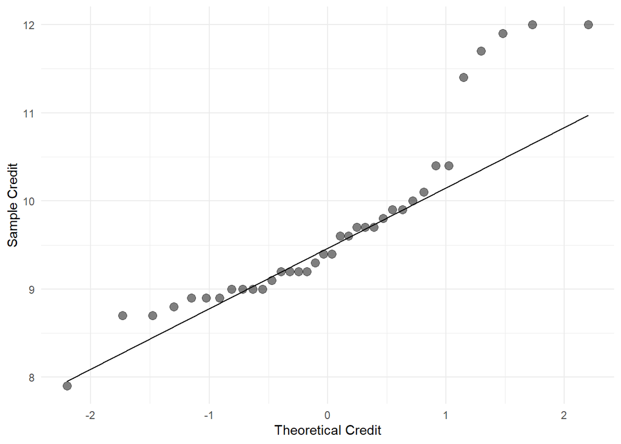

```r
credit_qq <- bonus_data %>%
  filter(Department == "Credit") %>%
  ggplot(aes(sample = Bonus)) +
  stat_qq(size=3, alpha = 0.5) +
  stat_qq_line() +
  theme_minimal() +
  xlab("Theoretical Credit") +
  ylab("Sample Credit")
credit_qq
```

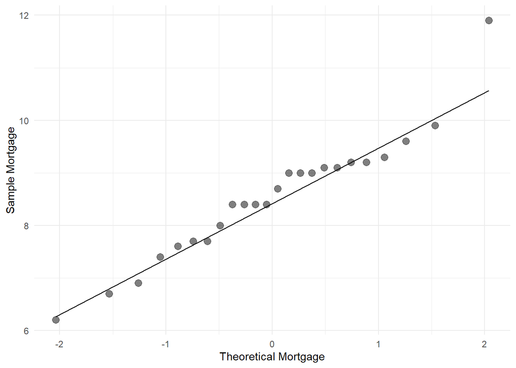

```r
mortgage_qq <- bonus_data %>%
  filter(Department == "Mortgage") %>%
  ggplot(aes(sample = Bonus)) +
    stat_qq(size=3, alpha = 0.5) +
    stat_qq_line() +
    theme_minimal() +
    xlab("Theoretical Mortgage") +
    ylab("Sample Mortgage")
mortgage_qq
```

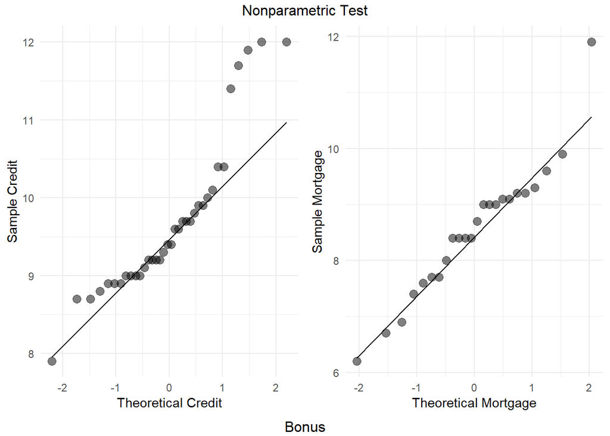

```r
# Combine both graphs
grid.arrange(credit_qq, mortgage_qq, nrow=1, bottom = "Bonus", top = "Nonparametric Test")
```

### Frequency Table

```r
# mean by department
groups_mean <- bonus_data %>%
  group_by(Department) %>%
  summarise(Mean = mean(Bonus),
            Median = median(Bonus))
change_table_format(groups_mean)
```

| Department | Mean | Median |
| --- | --- | --- |
| Credit | 9.683333 | 9.40 |
| Mortgage | 8.533333 | 8.55 |

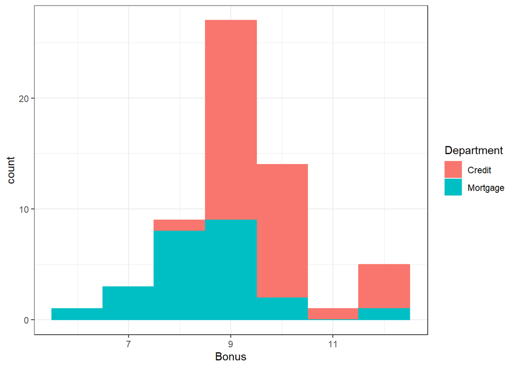

```r
# bonus histogram
bonus_data %>%
  group_by(Department) %>%
  ggplot(aes(x = Bonus, colour = Department, fill = Department)) +
  geom_histogram(binwidth = 1)+
  theme_bw()
```

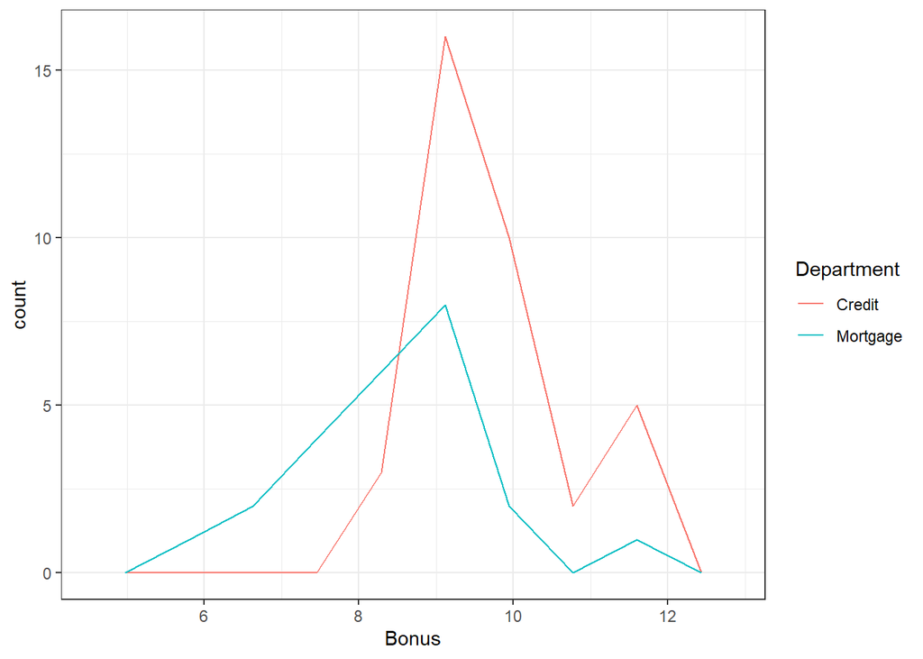

```r
# bonus frequency
bonus_data %>%
  group_by(Department) %>%
  ggplot(aes(x = Bonus, colour = Department, fill = Department)) +
  geom_freqpoly(bins = 8)+
  theme_bw()
```

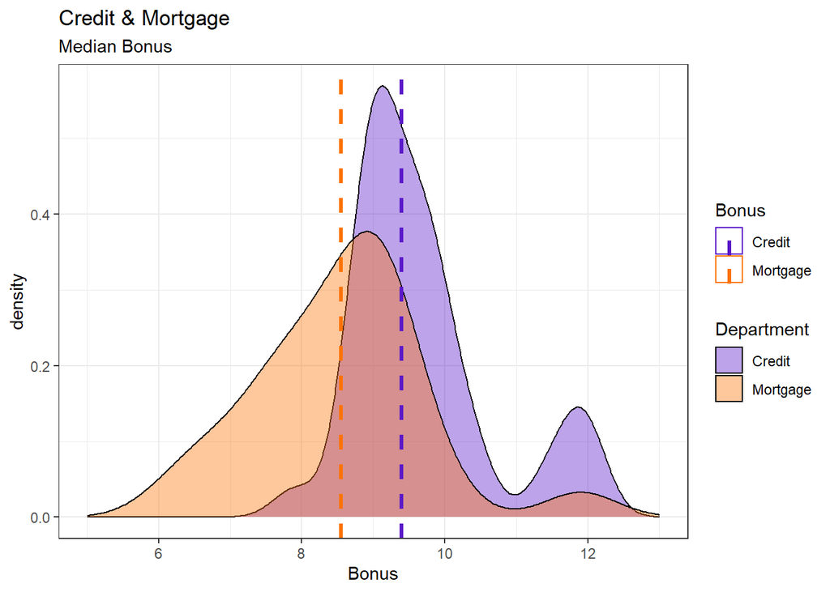

```r
# bonus density
bonus_data %>%
  group_by(Department) %>%
  ggplot(aes(x = Bonus, colour = Bonus, fill = Department)) +
  geom_density(alpha = 0.4)+
  geom_vline(data = groups_mean, aes(xintercept=Median, color=Department), linetype="dashed", size = 1.1)+
  xlim(5,13)+
  labs(title = "Credit & Mortgage", subtitle = "Median Bonus")+
  theme(legend.position="bottom")+
  theme_bw()+
  scale_fill_manual(values = custom_density_hue)+
  scale_color_manual(values = custom_density_hue)
```

The Wilcoxon nonparametric test and the QQ graph should be reported since the data is not normal distributed.

#### d. Write a brief paragraph explaining your findings to management, based on the test chosen in part c.

## Conclusion

The T-test demonstrated a difference of bonuses earned for both groups. However, during the assumption, QQ plot discrepancies are shown. Especially for the credit department, there are some outliers towards the right tail.

## Question 2:

**Recall the second dataset from last week. A new 2 hour reading comprehension program has been developed by a local tutoring center. A pilot study of 30 students has been conducted and we have data on a reading comprehension test taken before the program and a separate reading comprehension test taken after the program. Consider the data, found in the following Google Sheet.**

```r
# extract data
data <- as_tibble(gsheet2tbl("https://docs.google.com/spreadsheets/d/1ijxX7c6qcFAw-r_mNSxC-Ps5b5njw-WtE4RcxPTySXU/edit?usp=sharing"))

# transform data to Reading dataframe
reading_data <- data %>%
  # delete empty rows
  drop_na()
```

#### a. (From last week!) Use the appropriate *t*-test to determine if the program raises comprehension test averages by at least 5 points. Test at the α=0.05 level.

```r
# H0: Post <= Pre
# H1: Post > Pre
# mu = 5
t.test(data$Post, data$Pre,
       paired = TRUE,
       mu = 5,
       alternative = "greater")
```

```
    Paired t-test

data:  data$Post and data$Pre
t = -1.563, df = 29, p-value = 0.9356
alternative hypothesis: true mean difference is greater than 5
95 percent confidence interval:
 2.495512      Inf
sample estimates:
mean difference
            3.8
```

### Hypothesis

H0: $\mu Post \le \mu Pre$  
H1: $\mu Post > \mu Pre$

### Test

t0 = -1.56

### p-Value

p = 0.94

## Conclusion

Keep H0 at the $\alpha$=0.05 level. There is insufficient evidence to suggest that the program raises comprehension test averages by at least 5 points.

#### b. Use the appropriate nonparametric test to determine if the program raises comprehension test averages by at least 5 points. Test at the α=0.05 level.

```r
# nonparametric test for dependent groups
wilcox.test(reading_data$Post, reading_data$Pre,
            paired = TRUE,
            mu = 5,
            alternative = "greater",
            exact = FALSE)
```

```
    Wilcoxon signed rank test with continuity correction

data:  reading_data$Post and reading_data$Pre
V = 124.5, p-value = 0.9055
alternative hypothesis: true location shift is greater than 5
```

### Hypothesis

H0: $\mu Post \le \mu Pre$  
H1: $\mu Post > \mu Pre$

### Test

t0 = 124.5

### p-Value

p = 0.91

## Conclusion

Keep H0 at the $\alpha$=0.05 level. There is insufficient evidence to suggest that the program raises comprehension test averages by at least 5 points.

#### c. Assess the assumption(s) associated with the *t*-test in part a. In your assessment, determine if the *t*-test or the corresponding nonparametric test should be reported.

### Assumption

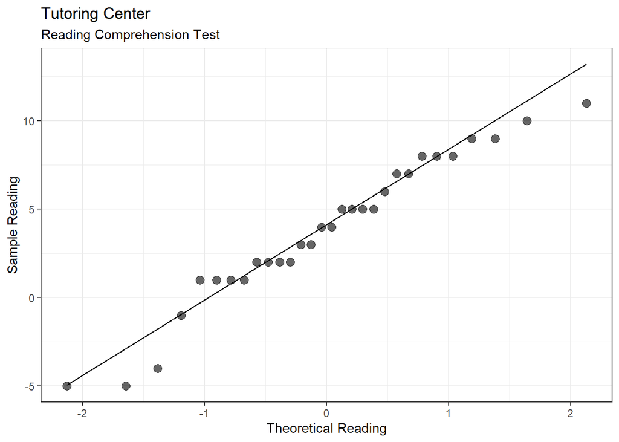

```r
graph_paired_qq_plot <- function(data_table, after_sample, before_sample){
  data_table %>%
    mutate(diff = after_sample - before_sample) %>%
    ggplot(aes(sample = diff)) +
    stat_qq(size=3, alpha = 0.6) +
    stat_qq_line() +
    theme_bw() +
    labs(title = "Tutoring Center", subtitle = "Reading Comprehension Test")+
    xlab("Theoretical Reading") +
    ylab("Sample Reading")
}
# Paired qq plot for Post - Pre reading scores
graph_paired_qq_plot(reading_data, reading_data$Post, reading_data$Pre)
```

### Frequency Reading

```r
# mean and median by dependent samples
# transform table from wide to long
data_long <- reading_data %>%
  drop_na() %>%
  pivot_longer(cols = Pre:Post,
               names_to = "Test",
               values_to = "Scores")
# summary statistics
summary_long_table <- data_long %>%
  group_by(Test) %>%
  select(Test, Scores) %>%
  summarise_all(list(Avg = mean,
                     Median = median))

change_table_format(summary_long_table)
```

| Test | Avg | Median |
| --- | --- | --- |
| Post | 75.23333 | 75.0 |
| Pre | 71.43333 | 72.5 |

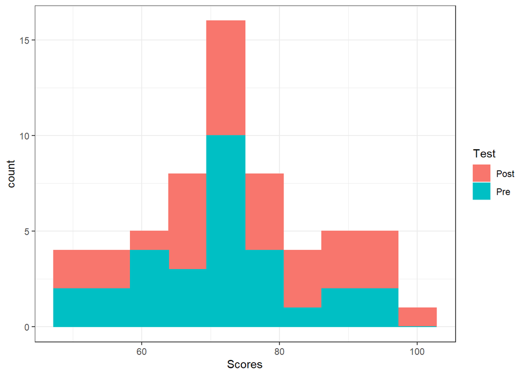

```r
# reading histogram
data_long %>%
  ggplot(aes(x = Scores, colour = Test, fill = Test)) +
  geom_histogram(bins = 10)+
  theme_bw()
```

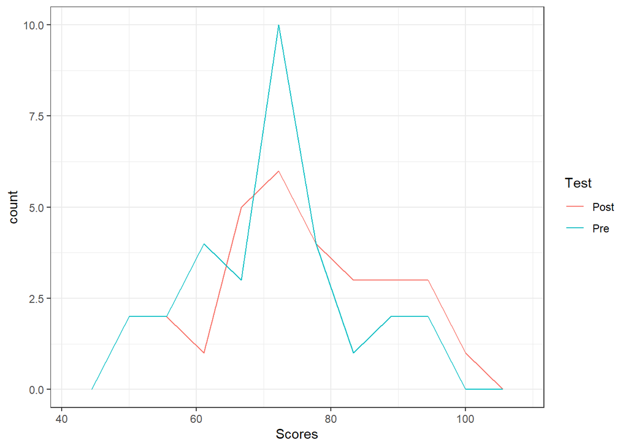

```r
# reading frequency
data_long %>%
  ggplot(aes(x = Scores, colour = Test, fill = Test)) +
  geom_freqpoly(bins = 10)+
  theme_bw()
```

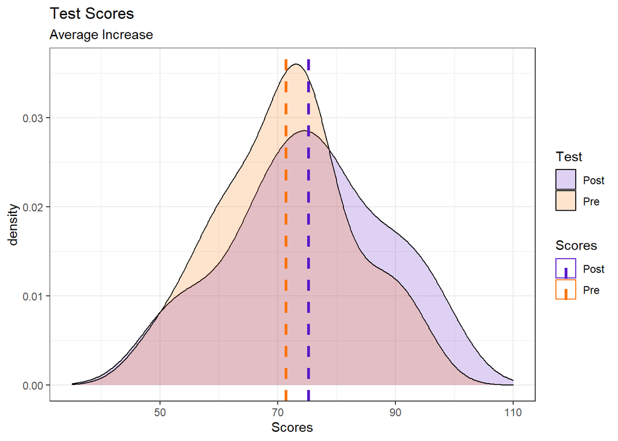

```r
# reading density
data_long %>%
  group_by(Test) %>%
  ggplot(aes(x = Scores, color = Scores, fill = Test)) +
  geom_density(alpha=0.2)+
  geom_vline(data = summary_long_table, aes(xintercept=Avg, color=Test), linetype="dashed", size = 1.1)+
  xlim(35,110)+
  labs(title = "Test Scores", subtitle = "Average Increase")+
  theme_bw()+
  scale_fill_manual(values = custom_density_hue)+
  scale_color_manual(values = custom_density_hue)
```

## Assumption Conclusion

The T-test should be reported since the test scores are normal distributed. It is adequate to assume normality. The density graph displays an improvement in the average scores.

#### d. Write a brief paragraph explaining your findings to the tutoring center, based on the test chosen in part c.

Even though the scores have improved, the grade average is not greater than 5 points. The tutoring department should continue working on the reading comprehension program. Yet, the reading comprehension program is not ready to be integrated into its curriculum. Moreover, a bigger sample size will help to confidently reach a conclusion.

### Function Tester

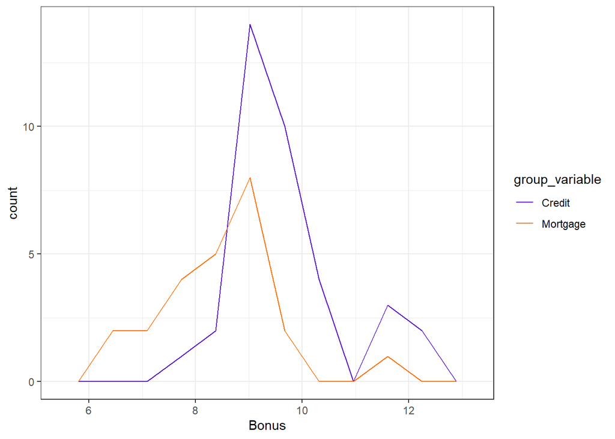

```r
# bonus frequency
freq_test <- function(data, group_variable, num_variable, x_num, group_legend){
  data %>%
    ggplot(aes(x = num_variable, colour = group_variable, fill = group_variable)) +
    geom_freqpoly(bins = 10)+
    theme_bw()+
    scale_color_manual(values = custom_density_hue)+
    xlab(x_num)+
    guides(fill = guide_legend(title = group_legend))
    # theme(legend.title = element_text(group_legend))
}

# bonus frequency
freq_test(bonus_data, bonus_data$Department, bonus_data$Bonus, "Bonus", "Department")
```

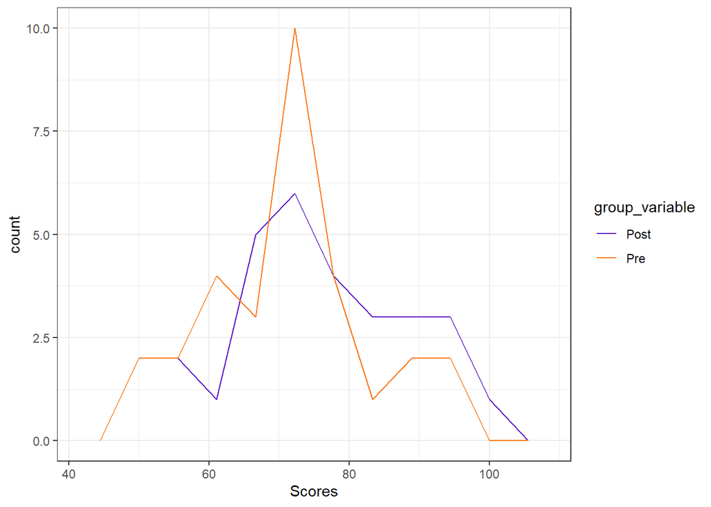

```r
# reading frequency
freq_test(data_long, data_long$Test, data_long$Scores, "Scores", "Test")
```

```r
# shapiro test
credit_department <- bonus_data %>%
  filter(Department == "Credit") %>%
  select(Bonus)

credit_department
```

```
# A tibble: 36 × 1
   Bonus
   <dbl>
 1  10.4
 2   8.9
 3  11.7
 4  12
 5   8.7
 6   9.4
 7   9.8
 8   9
 9   9.2
10   9.7
# … with 26 more rows
```

```r
shapiro.test(bonus_data$Bonus)
```

```
    Shapiro-Wilk normality test

data:  bonus_data$Bonus
W = 0.9384, p-value = 0.004595
```

```r
shapiro.test(reading_data$Pre)
```

```
    Shapiro-Wilk normality test

data:  reading_data$Pre
W = 0.98345, p-value = 0.908
```